# ESM204 HW3

Alex Ehrens

5/10/2020

```r
mwtpl <- hw3_data$price_dollars
mwtph <- hw3_data$price_dollars
ql <- hw3_data$q_low_gallons
qh <- hw3_data$q_high_gallons
```

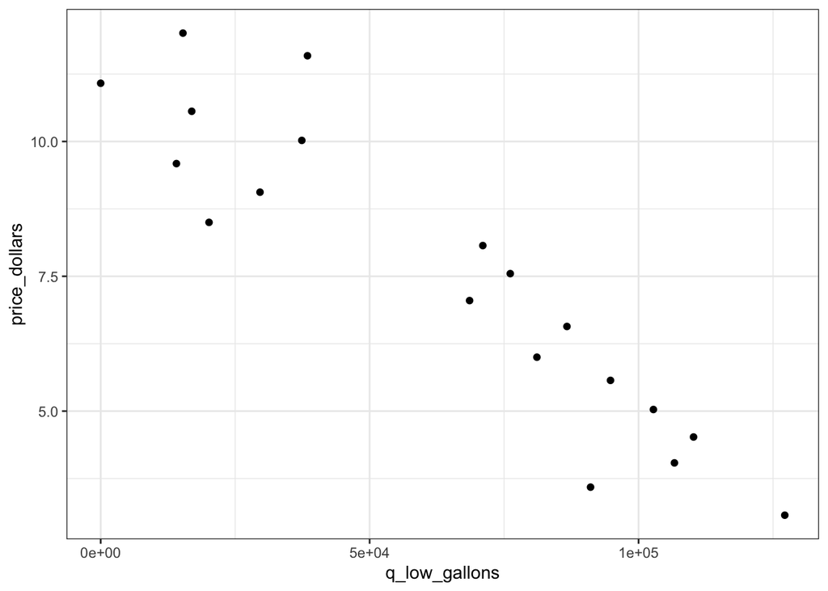

```r
# graph data
ggplot(data = hw3_data) +
  geom_point(aes(x = q_low_gallons,
                 y = price_dollars)) +
  theme_bw()
```

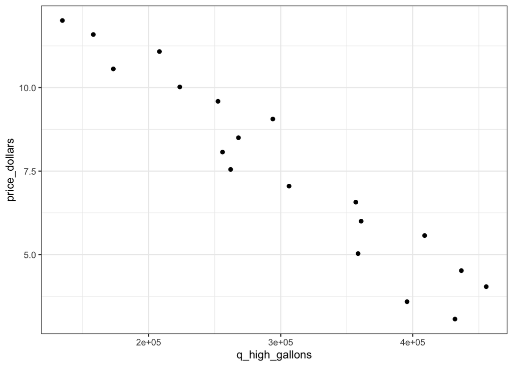

```r
ggplot(data = hw3_data) +
  geom_point(aes(x = q_high_gallons,
                 y = price_dollars)) +
  theme_bw()
```

```r
# make data frames for low and high income demand
low_df <- tibble(MWTP_L = mwtpl, Q_L = ql)
lm_low <- lm(MWTP_L ~ Q_L, data = low_df)
summary(lm_low)
```

```
##
## Call:
## lm(formula = MWTP_L ~ Q_L, data = low_df)
##
## Residuals:
##      Min       1Q   Median       3Q      Max
## -2.07412 -0.59931 -0.00643  0.71115  2.44635
##
## Coefficients:
##               Estimate Std. Error t value Pr(>|t|)
## (Intercept)  1.169e+01  4.918e-01  23.761 1.76e-14 ***
## Q_L         -6.611e-05  6.710e-06  -9.853 1.92e-08 ***
## ---
## Signif. codes:  0 '***' 0.001 '**' 0.01 '*' 0.05 '.' 0.1 ' ' 1
##
## Residual standard error: 1.118 on 17 degrees of freedom
## Multiple R-squared:  0.851,  Adjusted R-squared:  0.8422
## F-statistic: 97.08 on 1 and 17 DF,  p-value: 1.923e-08
```

```r
low_coef <- as.numeric(lm_low$coefficients) # Spot 1 is the intercept, spot 2 is coef
b_L <- low_coef[1]
a_L <- low_coef[2]

high_df <- tibble(MWTP_H = mwtph, Q_H = qh)
lm_high <- lm(MWTP_H ~ Q_H, data = high_df)
summary(lm_high)
```

```
##
## Call:
## lm(formula = MWTP_H ~ Q_H, data = high_df)
##
## Residuals:
##      Min       1Q   Median       3Q      Max
## -1.40915 -0.62875  0.05205  0.66142  1.28539
##
## Coefficients:
##               Estimate Std. Error t value Pr(>|t|)
## (Intercept)  1.580e+01  6.128e-01   25.79 4.53e-15 ***
## Q_H         -2.731e-05  1.932e-06  -14.13 7.92e-11 ***
## ---
## Signif. codes:  0 '***' 0.001 '**' 0.01 '*' 0.05 '.' 0.1 ' ' 1
##
## Residual standard error: 0.811 on 17 degrees of freedom
## Multiple R-squared:  0.9216, Adjusted R-squared:  0.917
## F-statistic: 199.8 on 1 and 17 DF,  p-value: 7.921e-11
```

```r
high_coef <- as.numeric(lm_high$coefficients) # Spot 1 is the intercept, spot 2 is coef
b_H <- high_coef[1]
a_H <- high_coef[2]
```

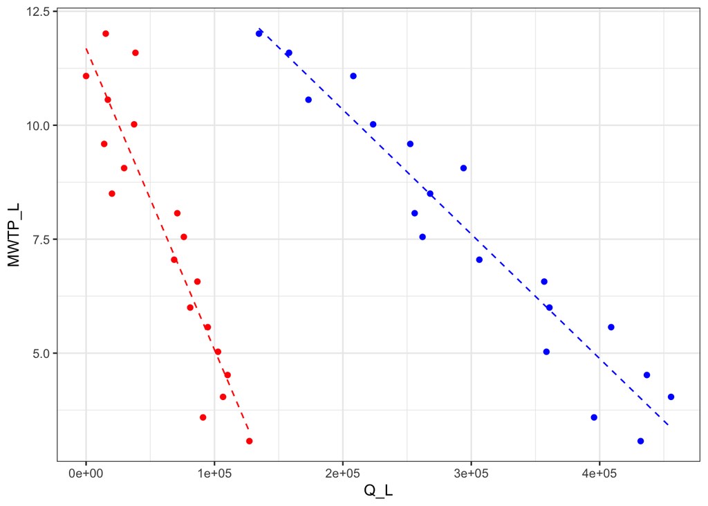

```r
# In this chunk I calculate the predicted willingness to pay for a given quantity for each consumer set and then graph them
low_df <- low_df %>%
  mutate(
    MWTP_predict = b_L + a_L*Q_L
  )

high_df <- high_df %>%
  mutate(
    MWTP_predict = b_H + a_H*Q_H
  )

ggplot() +
  geom_point(data = low_df, aes(x = Q_L, y = MWTP_L), color = 'red') +
  geom_line(data= low_df, aes(x = Q_L, y = MWTP_predict), color = 'red', lty = 2) +
  geom_point(data = high_df, aes(x = Q_H, y = MWTP_H), color = 'blue') +
  geom_line(data= high_df, aes(x = Q_H, y = MWTP_predict), color = 'blue', lty = 2) +
  theme_bw()
```

### 1. What is the aggregate daily demand curve for gasoline? What is the supply curve for gasoline? What is the “benefit” to consumers under the status quo? What is the “benefit” to producers under the status quo? What is the environmental cost under the status quo (locally and in the rest of the world)?

Say we have two linear demand curves of the following form:

- For lower income consumers: $P = b_L + a_L*Q_L$ Then, $Q_L = \frac{P - b_L}{a_L}$
- For higher income consumers: $P = b_H + a_H*Q_H$ Then, $Q_H = \frac{P - b_H}{a_H}$

Aggregate Daily Demand Curve = $Q_L + Q_H$

Supply Curve: $P = \frac{P_{eq}}{Q_{eq}}*Q_T$ where $P_{eq}$ is given and $Q_{eq}$ is found by calculating $Q_H + Q_L$ at $P_{eq}$. We know the intercept is 0, and the slope is just $\frac{rise}{run}$

```r
# From the "following stylized facts," we know that P_eq = $3.00
P_eq = 3
Q_L = (P_eq - b_L)/a_L
Q_H = (P_eq - b_H)/a_H
Q_eq = Q_H + Q_L

# Benefit to producers:
integrand_producers <- function(x) {(P_eq/Q_eq)*x}
integral_producers <- integrate(integrand_producers, 0, Q_eq)
benefit_producers.1 <- (P_eq*Q_eq) - as.numeric(integral_producers$value)

# Benefit to consumers (most easily found by doing each separately and then adding - THIS IS THE ANSWER TO QUESTION 2.):
integrand_low <- function(x) {b_L + a_L*x}
integral_low <- integrate(integrand_low, 0, Q_L)
benefit_low <- as.numeric(integral_low$value) - P_eq*Q_L

integrand_high <- function(x) {b_H + a_H*x}
integral_high <- integrate(integrand_high, 0, Q_H)
benefit_high <- as.numeric(integral_high$value) - P_eq*Q_H

benefit_consumers_1 = benefit_low + benefit_high

# Environmental costs: $1.50/gal locally, $0.50/gal globally
env_cost_local_1 = Q_eq*1.5
env_cost_global_1 = Q_eq*0.5
```

## Question 3.

The equation for the supply curve has changed, and is now $P = \frac{P_{eq}}{Q_{eq}}*Q_T + 1$ We must now solve for the new $P_{eq}$ to be plugged in below as P_eq.2

```r
#
t = 1
Q_eq.2 = (  (a_H/(a_H + a_L)*b_L) + (a_L/(a_H + a_L)*b_H) - t ) / ( (P_eq/Q_eq) -  (a_H*a_L)/(a_H + a_L)  )
P_eq.2 = (P_eq/Q_eq)*Q_eq.2 + t
Q_L.2 = (P_eq.2 - b_L)/a_L
Q_H.2 = (P_eq.2 - b_H)/a_H
# Benefit to producers:
integrand.producers <- function(x) {(P_eq/Q_eq)*x + t}
integral.producers <- integrate(integrand.producers, 0, Q_eq.2)
benefit.producers.2 <- (P_eq.2*Q_eq.2) - as.numeric(integral.producers$value)
# Benefit to consumers (most easily found by doing each separately and then adding - THIS IS THE ANSWER TO QUESTION 2.):
integrand.low <- function(x) {b_L + a_L*x}
integral.low <- integrate(integrand.low, 0, Q_L.2)
benefit.low.2 <- as.numeric(integral.low$value) - P_eq.2*Q_L.2
integrand.high <- function(x) {b_H + a_H*x}
integral.high <- integrate(integrand.high, 0, Q_H.2)
benefit.high.2 <- as.numeric(integral.high$value) - P_eq.2*Q_H.2
benefit.consumers.2 = benefit.low.2 + benefit.high.2
# Environmental costs: $1.50/gal locally, $0.50/gal globally
env.cost.local.2 = Q_eq.2*1.5
env.cost.global.2 = Q_eq.2*0.5
tax_revenue = Q_eq.2*t
```

```r
#Divide both demand equations by two
Q_eq.5 = (  (a_H/(a_H + a_L)*(b_L*0.5)) + (a_L/(a_H + a_L)*(b_H*0.5)) ) / (
  (P_eq/Q_eq) -  (a_H*a_L)/(a_H + a_L)  )
P_eq.5 = (P_eq/Q_eq)*Q_eq.5 # Gas Price
Q_L.5 = (P_eq.5 - b_L*0.5)/a_L # Low income consumption
Q_H.5 = (P_eq.5 - b_H*0.5)/a_H # High income consumption

# Compare these two numbers to those found in question 1.
env.cost.local.5 = Q_eq.5*1.5
env.cost.global.5 = Q_eq.5*0.5
```